# Political Speech and Divisiveness

2021-09-25

## Political Speech and Divisiveness

“Most citizens want a secure country, safe neighborhoods and good schools. These issues do get discussed, of course, but a disproportionate amount of attention goes to issues like abortion, medical marijuana, and other narrow issues that simply do not motivate the great majority.” Fiorina, Abrams, and Pope (2005), p. 202).

## Introduction

- Ash, Morelli, and Van Weelden (2017) use floor speeches by Members of the U.S. Congress and find that U.S. Senators spend more time on divisive issues when they are up for election.
- In this module, we will apply the model to the context of German politics.
- We use speech data from the German Bundestag, whereby we will investigate the impact of the election on September 22nd 2013.

## Research Question and Hypothesis

### Research question:

Do German politicians use more divisive language as soon as elections are close?

### Hypothesis

Greater posturing through divisive language is expected when electoral concerns are stronger.

## What is divisiveness?

- When voters are uncertain about an incumbent’s preferences, there is a pervasive incentive to “posture” by spending too much time on divisive issues (which are more informative about a politician’s preferences)
- This is at the expense of time spent on common-values issues (which provide greater benefit to voters).

## Dataset

- The raw text of the record from the German Bundestag can be obtained from the [official homepage](https://www.bundestag.de/dokumente/protokolle/plenarprotokolle).
- The text on each page of each document is split into two columns which is not correctly detected by the r function “readtext().” [Data in txt-format](https://www.bundestag.de/dokumente/protokolle/plenarprotokolle/plenarprotokolle) is available on the official homepage of the Bundestag only from 2013 to 2018.
- The website [offenesparlament.de](https://github.com/Datenschule/plpr-scraper/tree/master/data/txt) offers txt-data from 2009 to 2015.
- As this was the most complete dataset available, I chose to analyze this set of texts. Parsed and preprocessed .csv files are available [here](https://github.com/bundestag/plpr-scraper) and [here](https://github.com/sebas-seck/plpr-scraper).

```
## [1] 592199     12
```

```
##        id sitzung wahlperiode in_writing                               speaker
## 1 2323997       1          17          0 Alterspräsident Dr. Heinz Riesenhuber
## 2 2323998       1          17          0
## 3 2323999       1          17          0 Alterspräsident Dr. Heinz Riesenhuber
## 4 2324000       1          17          0
## 5 2324001       1          17          0 Alterspräsident Dr. Heinz Riesenhuber
## 6 2324002       1          17          0
##         speaker_cleaned        speaker_fp sequence
## 1 Dr. Heinz Riesenhuber heinz-riesenhuber        0
## 2                                                1
## 3 Dr. Heinz Riesenhuber heinz-riesenhuber        2
## 4                                                3
## 5 Dr. Heinz Riesenhuber heinz-riesenhuber        4
## 6                                                5
##                                                                                                                                                                                                                                                                                                          …
## 1 Guten Morgen, meine sehr verehrten Damen und Herren! Liebe Kolleginnen und Kollegen, ich begrüße Sie zur konstituierenden Sitzung des 17. Deutschen Bundestags.\n\nParlamentarischer Brauch ist es - das entspricht unserer Geschäftsordnung; ich kann die Paragrafen zitieren -, dass der Älteste die …
## 2                                                                                                                                                                                                                                                                                                        …
## 3                                                                                                                                   Unser Präsident würde sagen: Ich höre und sehe keinen Widerspruch.\n\nMeine Damen und Herren, damit rufe ich Punkt 1 der Tagesordnung auf:\n\nEröffnung der Sitzung d…
## 4                                                                                                                                                                                                                                                                                                        …
## 5                                                                                                                                                                                                                                                                                                        …
## 6                                                                                                                                                                                                                                                                                                        …
##             filename  type speaker_party
## 1 data/txt/17001.txt chair
## 2 data/txt/17001.txt   poi
## 3 data/txt/17001.txt chair
## 4 data/txt/17001.txt   poi
## 5 data/txt/17001.txt chair
## 6 data/txt/17001.txt   poi
```

## Choosing two parties

- The divisiveness measure used by Ash, Morelli, and Van Weelden (2017) is tailored to a two-party system.
- Unlike the U.S. political system, the German parliament consists of more than two parties, therefore a multidimensional approach to measure divisiveness would be needed.
- To keep it simple, we’ll work with a two-dimensional approach in this tutorial. Therefore, we subset the dataset, including those two parties for which the most speech data is recorded: CDU/CSU and the SPD.

```r
dim(txt2)[1]
```

```
## [1] 263328
```

```r
txt2<-txt2[txt2$speaker_party =="spd" | txt2$speaker_party =="cducsu",]
dim(txt2)[1]
```

```
## [1] 118419
```

## The Election Treatment

\(E_{it}\) represents the election treatment, which equals \(1\) for the first and \(4\) for the last year of the “Legislaturperiode” (currently up for election).

election: 27.09.2009

|\(E_{it}=1\) | 10.2009-10.2010 | |\(E_{it}=2\) | 11.2010-10.2011 | |\(E_{it}=3\) | 11.2011-10.2012 | |\(E_{it}=4\) | 11.2012-09.2013 |

election: 22.09.2013

|\(E_{it}=1\) | 10.2013-10.2014 | |\(E_{it}=2\) | 11.2014-10.2015 | |\(E_{it}=3\) | 11.2015-10.2016 |  
|\(E_{it}=4\) | 11.2016-09.2017 |

election: 24.09.2017

## Select Speaker

In the next step, we reduce the number of speakers:  
Only politicians who spoke in all four years and from whom enough speech data (more than 500 sentences) are available, are included.

```r
print(head(unique(txt2$speaker_fp)))
```

```
## [1] "volker-kauder"     "gerda-hasselfeldt" "joachim-poß"
## [4] "sascha-raabe"      "rainer-arnold"     "rolf-mutzenich"
```

Overall, 48 speakers are included in the df.

## Prepare

```r
print(sum(ntoken(txt.t)))
```

```
## [1] 315564
```

```r
source('scr_R/toexclude.R')
txt.t<-tokens_select(txt.t, toexclude, selection = "remove", padding = FALSE)
print(sum(ntoken(txt.t)))
```

```
## [1] 315564
```

```r
bitri<- tokens_ngrams(txt.t, 1:2) #generate ngrams
sum(ntoken(bitri))
```

```
## [1] 620720
```

```r
phi_ikt<-dfm_trim(dfm_group(dfm(bitri), groups = interaction(E_jt, speaker_fp, speaker_party)),
         min_docfreq = 10,
         min_termfreq = 10)
k<-colnames(phi_ikt)
```

## Construct frequency-weighted phrase divisiveness

\(Y_{it}\) measures the divisiveness of speech.

\[ Y_{it} = log(\sum_{k=1}^{K}{\frac{f_{ikt} \cdot \chi_{kt}^2}{F_{it}}}) \]

### Political Divisiveness Metric

It is constructed as follows.

- \(n_{kt}^{CDU}\): the number of times phrase \(k\) is used by CDU/CSU-politicians during session \(t\).
- \(N_{t}^{CDU} = \sum_{k}n_{kt}^{CDU}\) are summed frequencies of all phrases used by CDU/CSU-politicians in session \(t\).
- \(\tilde{n}_{kt}^{CDU} = N_{t}^{CDU} - n_{kt}^{CDU}\): total number of times phrases besides \(k\) were used by CDU/CSU-politicians.

- \(\chi_{kt}^2\) provides a test statistic for the null hypothesis that phrase \(k\) is used equally by CDU/CSU and SPD-politicians during session \(t\)
- If the frequencies \(n_{kt}^{CDU}\) and \(n_{kt}^{SPD}\) are drawn from multinomial distributions.
- \(\chi_{kt}^2\) scores language as divisive if it is used more often by just one of the political parties.

We start constructing \(\chi_{kt}^2\) by calculating \(N_{cdu}\) and \(N_{spd}\)

```r
df.spd<-as.data.frame(dfm_subset(dfm_kt, substrRight(rownames(dfm_kt), 3)=="spd"))
df.spd<-df.spd[,-1]
N_spd<-rowSums(df.spd)
print(N_spd)
```

```
## [1] 33432 40256 27371 25970
```

\(\chi_{kt}^2\) is then constructed as follows:

```r
for(i in 1:dim(chi2)[1]){
  for(j in 1:dim(chi2)[2]){
    n_cdu<-df.cdu[i,j]
    n_spd<-df.spd[i,j]

    nt_cdu<-(N_cdu[i]-n_cdu)
    nt_spd<-(N_spd[i]-n_spd)

    chi2[i,j]<- (((n_cdu*nt_spd-n_spd*nt_cdu)^2)/(N_cdu[i]*N_spd[i]*(n_cdu+n_spd)*(nt_cdu+nt_spd)))
  }
}
print(chi2[,1:5])
```

```
##           herr       schlag          cdu csu-bundestagsfraktion       kolleg
## 1 6.568571e-07 5.482490e-06 1.412241e-07           4.612296e-05 1.489920e-08
## 2 4.984577e-05 2.771119e-05 4.369747e-06           1.312967e-04 6.174415e-05
## 3 5.493215e-06 2.590559e-05 2.724664e-05           1.207878e-05 3.853084e-05
## 4 1.264917e-04 3.001461e-07 1.467119e-05           1.415608e-05 1.063916e-04
```

According to \(\chi_{kt}^2\), the 10 most and least divisive phrases in the dataset are:

```
##       Most Divisive Phrases        Least Divisive Phrases
##  [1,] "cdu"                        "bekampf_fluchtursach"
##  [2,] "cdu_csu-bundestagsfraktion" "dass_allein"
##  [3,] "csu-bundestagsfraktion"     "dass_mittel"
##  [4,] "gern"                       "gut_haushalt"
##  [5,] "herr"                       "hajduk"
##  [6,] "kolleg"                     "lotzsch"
##  [7,] "nehm"                       "sozial_wohnungsbau"
##  [8,] "prasident"                  "sterb"
##  [9,] "schlag"                     "viel_fluchtling"
## [10,] "wahl"                       "wohnungsbau"
```

### Normalized Frequency

- Just a reminder: Our goal is to calculate \(Y_{it}\)

\[ Y_{it} = log(\sum_{k=1}^{K}{\frac{f_{ikt} \cdot \chi_{kt}^2}{F_{it}}}) \]

- We just calculated \(\chi_{kt}^2\)
- Now, we proceed with \(f_{ikt}\)
- The normalized frequency \(f_{ikt}\) is constructed such that it shows zero mean and standard deviation one (z-score centering, function `scale()`).
- This means that each phrase has the same influence on the divisiveness measure. \[ f_{ikt}:=\frac{\phi_{ikt}-\mu_{kt}}{\sigma_{kt}} \]

\[ f_{ikt}:=\frac{\phi_{ikt}-\mu_{kt}}{\sigma_{kt}} \]

That’s \(\phi_{ikt}\):

```r
phi_ikt[1:5,1:5]
```

```
## Document-feature matrix of: 5 documents, 5 features (52.0% sparse) and 3 docvars.
##                             features
## docs                         herr schlag cdu csu-bundestagsfraktion kolleg
##   1.armin-schuster.cducsu      33      0   0                      0     11
##   2.armin-schuster.cducsu       9      0   0                      0      2
##   3.armin-schuster.cducsu      19      0   1                      1      6
##   4.armin-schuster.cducsu      22      0   0                      0      4
##   1.bartholomaus-kalb.cducsu    3      0   0                      0      2
```

\[ f_{ikt}:=\frac{\phi_{ikt}-\mu_{kt}}{\sigma_{kt}} \]

That’s \(\mu_{kt}\):

```
## # A tibble: 8 x 5
## # Groups:   t [4]
##   t     c       herr schlag   cdu
##   <chr> <chr>  <dbl>  <dbl> <dbl>
## 1 1     cducsu 13.8   0.24  1.6
## 2 1     spd    12.0   0.304 1.39
## 3 2     cducsu 12.3   0.44  0.92
## 4 2     spd    13.8   0.174 1.04
## 5 3     cducsu 10.5   0.04  0.64
## 6 3     spd     9.22  0.130 0.826
## 7 4     cducsu 10.1   0.32  0.56
## 8 4     spd    11.4   0.304 0.696
```

\[ f_{ikt}:=\frac{\phi_{ikt}-\mu_{kt}}{\sigma_{kt}} \]

That’s \(\sigma_{ikt}\)

```r
sigma_ikt<-as.data.frame(phi_ikt)
sigma_ikt$t<-tik[,1]
sigma_ikt$c<-tik[,3]
sigma_ikt<-sigma_ikt[,-1]
sigma_kt<- sigma_ikt %>%
  group_by(t,c) %>%
  dplyr::summarise(across(.cols = everything(),
                   ~ sd(.x, na.rm = TRUE)))
sigma_kt[,1:5]
```

```
## # A tibble: 8 x 5
## # Groups:   t [4]
##   t     c       herr schlag   cdu
##   <chr> <chr>  <dbl>  <dbl> <dbl>
## 1 1     cducsu 12.0   0.723 2.06
## 2 1     spd    13.9   1.06  1.80
## 3 2     cducsu  7.93  1.08  1.44
## 4 2     spd     9.89  0.491 1.66
## 5 3     cducsu  7.25  0.2   0.952
## 6 3     spd    11.2   0.458 1.19
## 7 4     cducsu  7.34  0.748 1.26
## 8 4     spd     9.17  0.635 1.11
```

And here we finally have \(f_{ikt}\)

\[ f_{ikt}:=\frac{\phi_{ikt}-\mu_{kt}}{\sigma_{kt}} \]

```r
f_ikt <- as.data.frame(t(apply(phi_ikt, 1, scale))) #mean over rows
colnames(f_ikt)<-colnames(phi_ikt)
f_ikt[1:5,1:5]
```

```
##                                 herr     schlag        cdu
## 1.armin-schuster.cducsu    17.622613 -0.2781990 -0.2781990
## 2.armin-schuster.cducsu    20.958509 -0.1942175 -0.1942175
## 3.armin-schuster.cducsu    12.006459 -0.3128585  0.3355267
## 4.armin-schuster.cducsu    17.664667 -0.2780650 -0.2780650
## 1.bartholomaus-kalb.cducsu  5.721011 -0.2203030 -0.2203030
##                            csu-bundestagsfraktion   kolleg
## 1.armin-schuster.cducsu                -0.2781990 5.688738
## 2.armin-schuster.cducsu                -0.1942175 4.506388
## 3.armin-schuster.cducsu                 0.3355267 3.577452
## 4.armin-schuster.cducsu                -0.2780650 2.984250
## 1.bartholomaus-kalb.cducsu             -0.2203030 3.740573
```

### Total Number of Phrases Spoken

- Remember our goal is to calculate \(Y_{it}\)

\[ Y_{it} = log(\sum_{k=1}^{K}{\frac{f_{ikt} \cdot \chi_{kt}^2}{F_{it}}}) \]

```
##                                     F_it
## 1.armin-schuster.cducsu    -5.451195e-14
## 2.armin-schuster.cducsu     8.593126e-14
## 3.armin-schuster.cducsu     8.970602e-14
## 4.armin-schuster.cducsu     3.202993e-14
## 1.bartholomaus-kalb.cducsu  9.503509e-14
## 2.bartholomaus-kalb.cducsu  1.443290e-14
```

## Politician Divisiveness

Politician divisiveness \(Y_{it}\) is defined as the frequency-weighted phrase divisiveness for the phrases used by the member. \[ Y_{it} = log(\sum_{k=1}^{K}{\frac{f_{ikt} \cdot \chi_{kt}^2}{F_{it}}}) \]

## Plot

In the followig we plot a histogram of \(Y_{it}\)

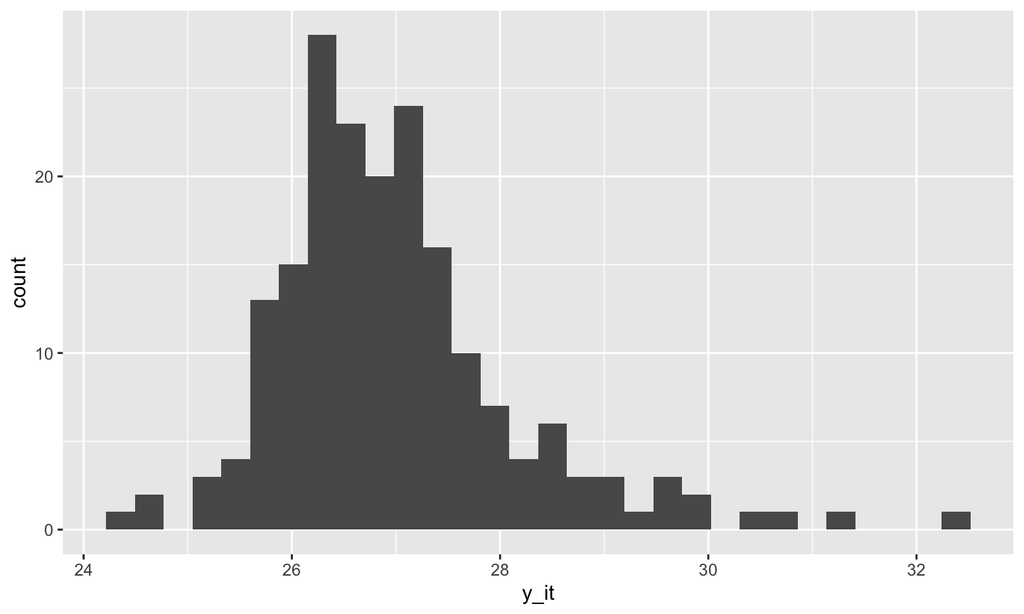

- The following figure plots average politicians’ speech divisiveness over the course of the four years of a “Legislaturperiode.”
- Error spikes indicate the 95% confidence interval.

```
## geom_path: Each group consists of only one observation. Do you need to adjust
## the group aesthetic?
```

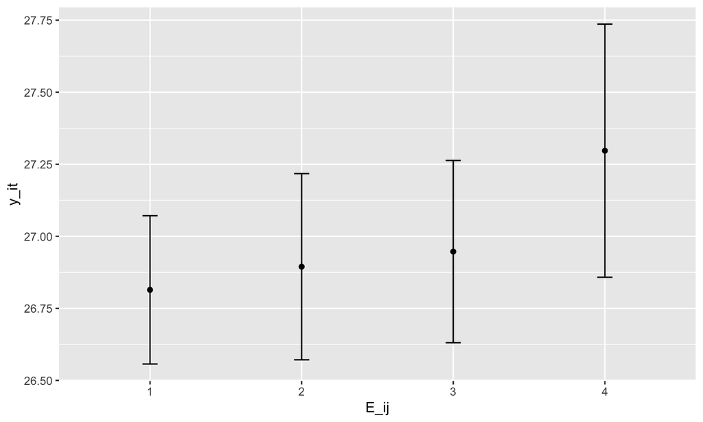

## Fixed Effects Regression

\[ Y_{it} = \alpha_{it} + \rho_EE_{it} + \epsilon_{it} \]

\[ Y_{it} = \alpha_{it} + \rho_EE_{it} + \epsilon_{it} \]

```
##
## Call:
##    felm(formula = y_it ~ E_ij | factor(party), data = Y_it2, exactDOF = TRUE)
##
## Residuals:
##     Min      1Q  Median      3Q     Max
## -2.6616 -0.7483 -0.1938  0.4685  5.0140
##
## Coefficients:
##       Estimate Std. Error t value Pr(>|t|)
## E_ij2   0.0804     0.2375   0.339   0.7353
## E_ij3   0.1327     0.2375   0.559   0.5769
## E_ij4   0.4828     0.2375   2.033   0.0435 *
## ---
## Signif. codes:  0 '***' 0.001 '**' 0.01 '*' 0.05 '.' 0.1 ' ' 1
##
## Residual standard error: 1.163 on 187 degrees of freedom
## Multiple R-squared(full model): 0.04417   Adjusted R-squared: 0.02373
## Multiple R-squared(proj model): 0.02516   Adjusted R-squared: 0.004307
## F-statistic(full model): 2.16 on 4 and 187 DF, p-value: 0.0751
## F-statistic(proj model): 1.609 on 3 and 187 DF, p-value: 0.1888
```

## Linear Model

```r
reg1<-lm(Y_it$y_it~Y_it$E_ij)
summary(reg1)
```

```
##
## Call:
## lm(formula = Y_it$y_it ~ Y_it$E_ij)
##
## Residuals:
##     Min      1Q  Median      3Q     Max
## -2.4906 -0.7465 -0.1743  0.5276  5.1850
##
## Coefficients:
##             Estimate Std. Error t value Pr(>|t|)
## (Intercept)  26.8142     0.1692 158.491   <2e-16 ***
## Y_it$E_ij2    0.0804     0.2393   0.336    0.737
## Y_it$E_ij3    0.1327     0.2393   0.555    0.580
## Y_it$E_ij4    0.4828     0.2393   2.018    0.045 *
## ---
## Signif. codes:  0 '***' 0.001 '**' 0.01 '*' 0.05 '.' 0.1 ' ' 1
##
## Residual standard error: 1.172 on 188 degrees of freedom
## Multiple R-squared:  0.02467,    Adjusted R-squared:  0.009105
## F-statistic: 1.585 on 3 and 188 DF,  p-value: 0.1944
```

## References

Ash, Elliott, Massimo Morelli, and Richard Van Weelden. 2017. “ Elections and divisiveness: Theory and evidence.” *The Journal of Politics* 79 (4): 1268–85.

Fiorina, Morris P, Samuel J Abrams, and Jeremy C Pope. 2005. “ Culture war.” *The Myth of a Polarized America* 3.